# **Panorama da inflação**

Os principais índices de inflação do Brasil, apontam em junho de 2004 um avanço da inflação de em média **0.86%**. Com esse resultado, no ano a inflação acumula uma variação média positiva de **4.16%**, e em 12 meses uma variação média acumulada de **7.08%**.

[output not shown]

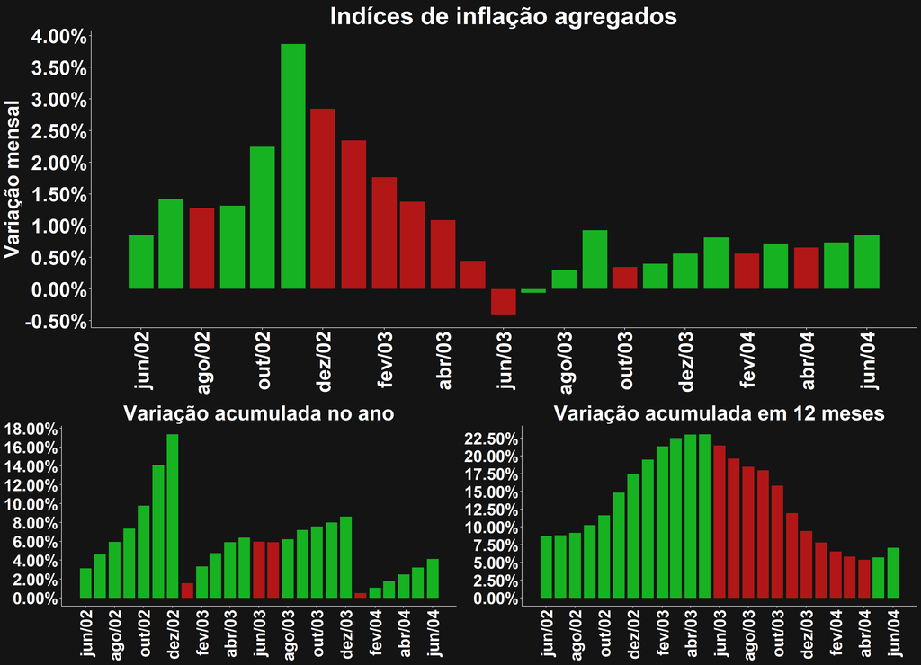

Índices selecionados para a média: IPCA, INPC e IGP-M.

# IPCA

O Indíce de Preços ao Consumidor Amplo (IPCA) variou 0.71% em junho, valor superior ao mesmo período do ano anterior quando apresentou uma taxa de -0.15%. Com esse resultado o indíce acumula no ano uma variação positiva de 3.48%, e em 12 meses uma variação positiva de 6.06%.

|  | 06/2003 | 05/2004 | 06/2004 |
| --- | --- | --- | --- |
| Variação mensal | -0.15% | 0.51% | 0.71% |
| Variação acumulada no ano | 6.64% | 2.75% | 3.48% |
| Variação acumulada em 12 meses | 16.57% | 5.15% | 6.06% |

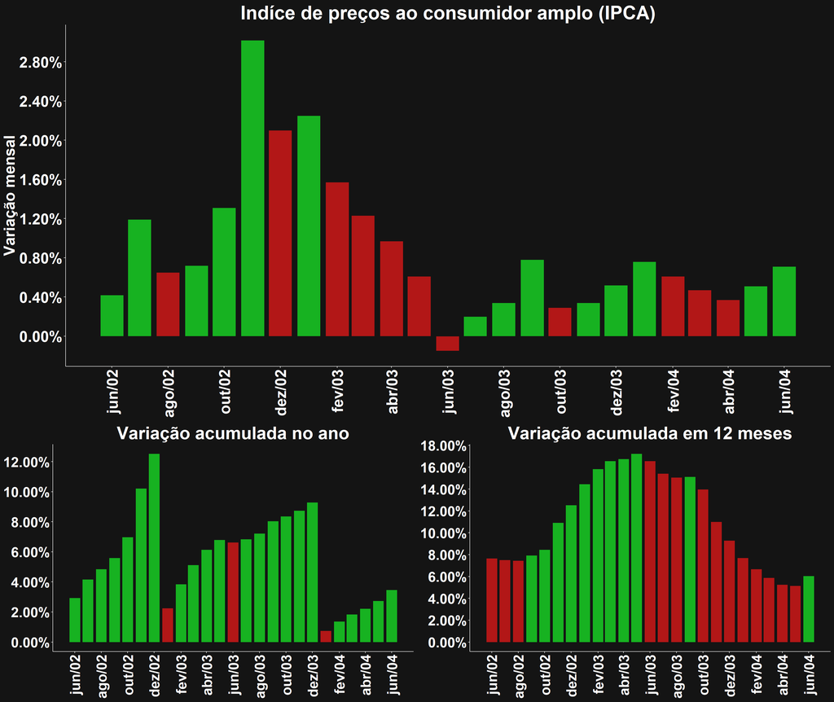

|  | Variação mensal | Variação acumulada no ano | Peso mensal |
| --- | --- | --- | --- |
| Alimentação e bebidas | 0.72% | 2.08% | 23.05% |
| Habitação | 0.2% | 3.73% | 16.7% |
| Artigos de residência | 0.63% | 2.76% | 5.57% |
| Vestuário | 1.14% | 3.9% | 5.23% |
| Transportes | 1.58% | 3.51% | 21.02% |
| Saúde e cuidados pessoais | 0.42% | 4.8% | 10.65% |
| Despesas pessoais | 0.3% | 3.1% | 9.16% |
| Educação | 0.19% | 9% | 4.91% |
| Comunicação | 0.06% | 1.83% | 3.7% |

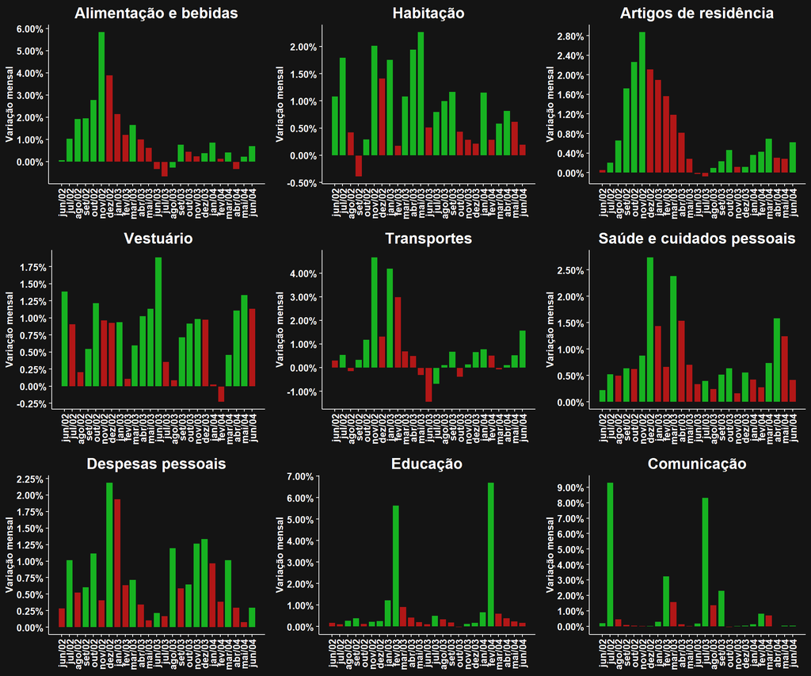

A nível de sub-itens os que mais influenciaram positivamente no resultado em relação ao seu peso foram Gasolina (3.52%%) e Etanol (11.35%%), e negativamente Óleo de soja (-3.1%%) e Arroz (-0.96%%).

|  | Variação mensal | Variação acumulada no ano | Peso mensal |
| --- | --- | --- | --- |
| Leite pasteurizado | 5.33% | 12.17% | 1.34% |
| Gasolina | 3.52% | 1.43% | 3.86% |
| Etanol | 11.35% | -5.6% | 0.78% |
| Automóvel novo | 1.13% | 8.77% | 2.97% |

|  | Variação mensal | Variação acumulada no ano | Peso mensal |
| --- | --- | --- | --- |
| Arroz | -0.96% | -2.65% | 1.05% |
| Banana - prata | -10.7% | 4.06% | 0.08% |
| Mamão | -16.94% | 56.94% | 0.05% |
| Óleo de soja | -3.1% | 5.9% | 0.44% |

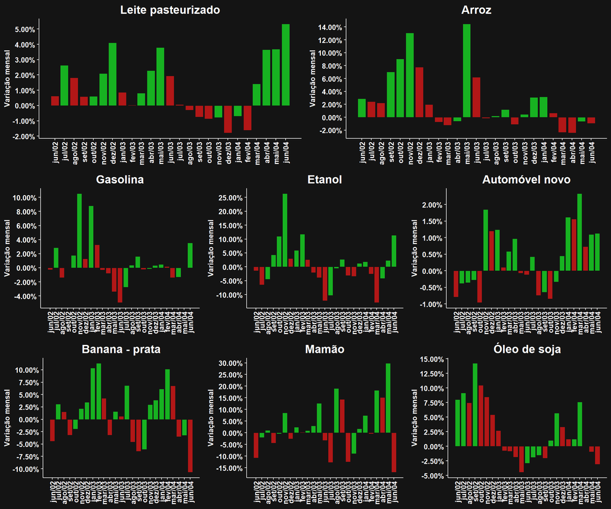

# INPC

O Indíce Nacional de Preços ao Consumidor (INPC) variou 0.5% em junho, valor superior ao mesmo período do ano anterior quando apresentou uma taxa de -0.06%. Com esse resultado o indíce acumula no ano uma variação positiva de 3.14%, e em 12 meses uma variação positiva de 5.57%.

|  | 06/2003 | 05/2004 | 06/2004 |
| --- | --- | --- | --- |
| Variação mensal | -0.06% | 0.4% | 0.5% |
| Variação acumulada no ano | 7.84% | 2.63% | 3.14% |
| Variação acumulada em 12 meses | 19.64% | 4.99% | 5.57% |

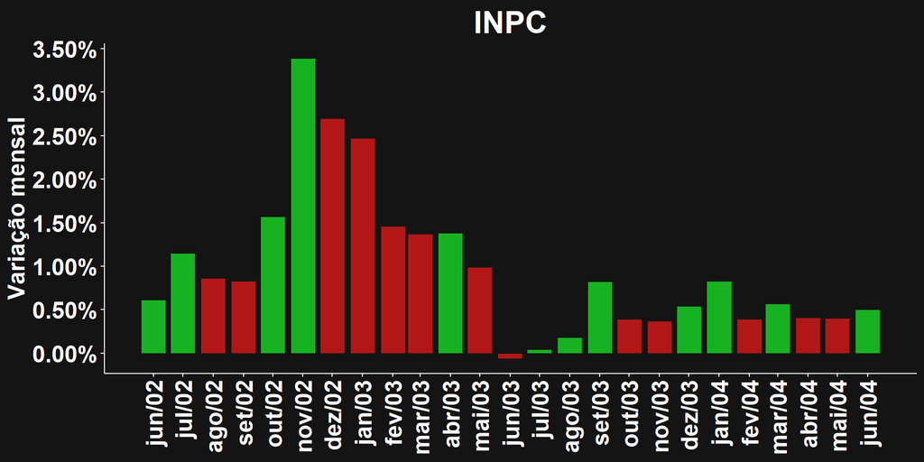

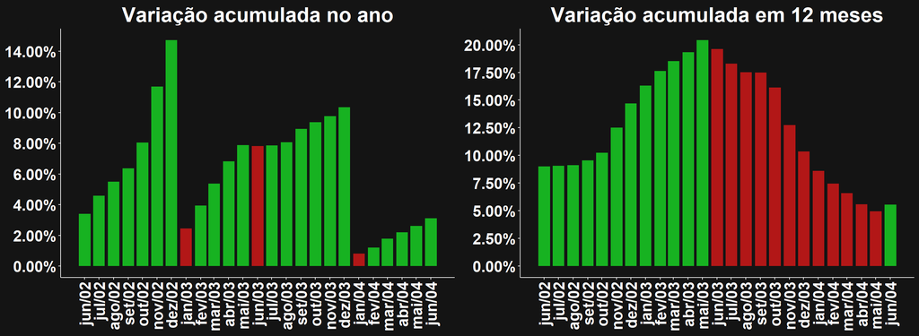

# IGP-M

O Indíce Geral de Preços de Mercado (IGP-M) variou 1.38% em junho, valor superior ao mesmo período do ano anterior quando apresentou uma taxa de -1%. Com esse resultado o indíce acumula no ano uma variação positiva de 5.85%, e em 12 meses uma variação positiva de 9.61%.

|  | 06/2003 | 05/2004 | 06/2004 |
| --- | --- | --- | --- |
| Variação mensal | -1% | 1.31% | 1.38% |
| Variação acumulada no ano | 3.49% | 4.41% | 5.85% |
| Variação acumulada em 12 meses | 28.23% | 7.04% | 9.61% |

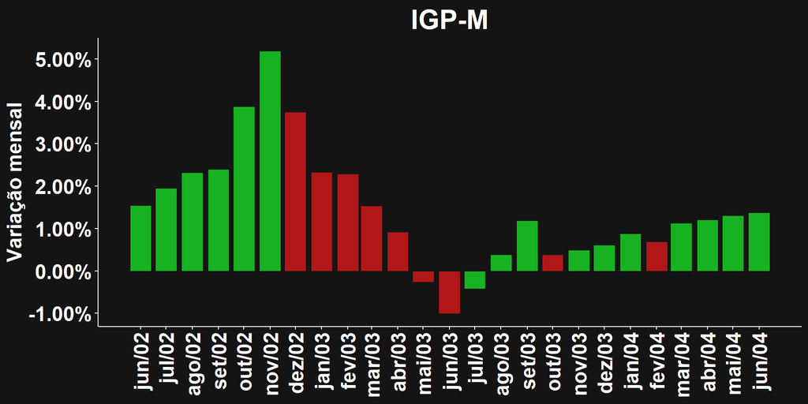

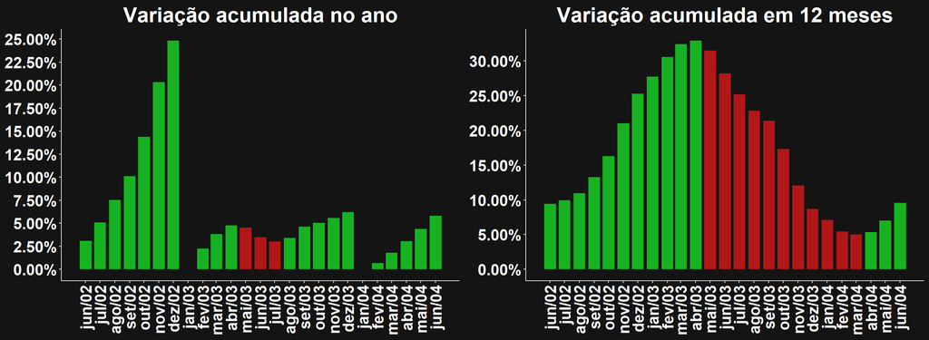

# IGP-DI

O Indíce Geral de Preços - Disponibilidade Interna (IGP-DI) variou 1.29% em junho, valor superior ao mesmo período do ano anterior quando apresentou uma taxa de -0.7%. Com esse resultado o indíce acumula no ano uma variação positiva de 6.05%, e em 12 meses uma variação positiva de 10.13%.

|  | 06/2003 | 05/2004 | 06/2004 |
| --- | --- | --- | --- |
| Variação mensal | -0.7% | 1.46% | 1.29% |
| Variação acumulada no ano | 2.29% | 4.71% | 6.05% |
| Variação acumulada em 12 meses | 26.94% | 7.97% | 10.13% |

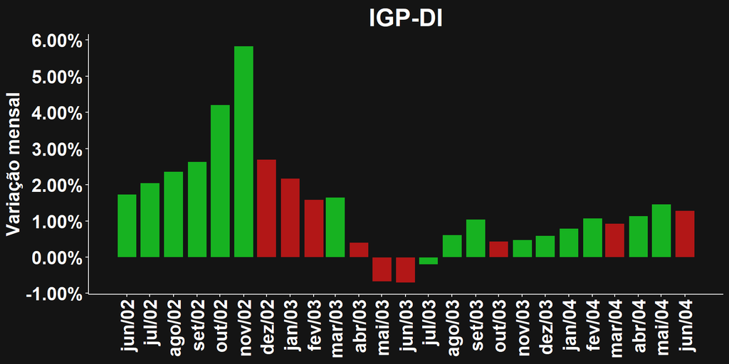

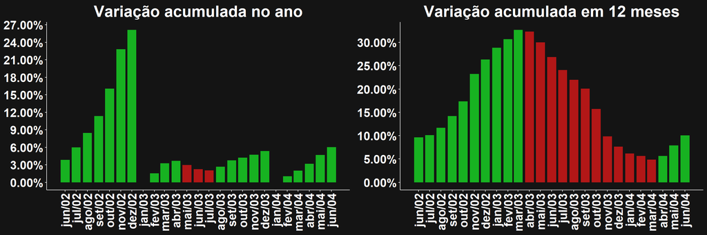

[output not shown]

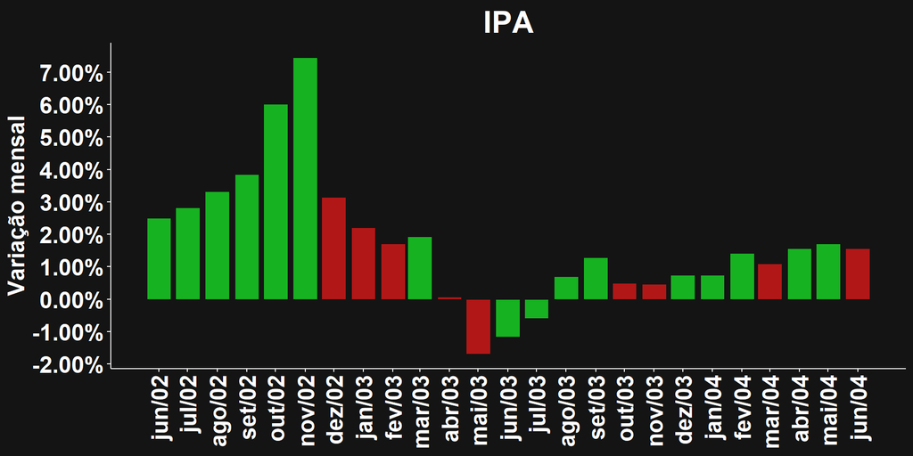

[figure not shown]

O Indíce de Preços ao Consumidor (IPC), integrante do IGP-DI com peso de 30%, apresentou variação de 0.78% em junho, valor superior ao mesmo período do ano anterior quando apresentou uma taxa de -0.16%. Com esse resultado o indíce acumula no ano uma variação positiva de 2.56%, e em 12 meses uma variação positiva de 5.99%.

|  | 06/2003 | 05/2004 | 06/2004 |
| --- | --- | --- | --- |
| Variação mensal | -0.16% | 0.71% | 0.78% |
| Variação acumulada no ano | 4.14% | 1.77% | 2.56% |
| Variação acumulada em 12 meses | 16.12% | 5% | 5.99% |

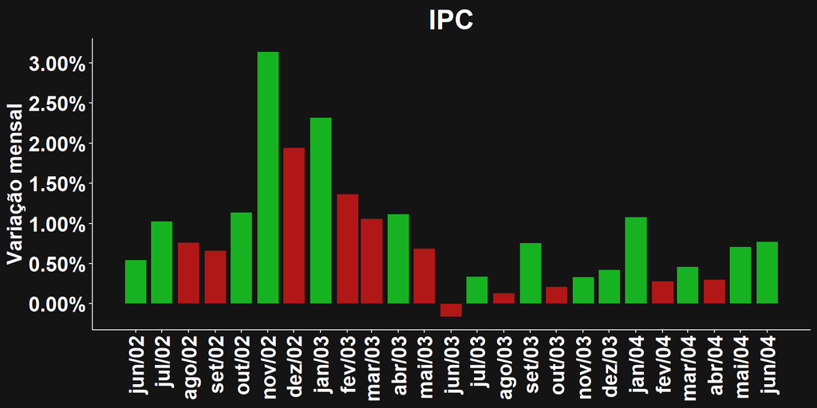

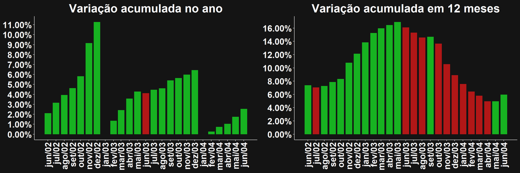

|  | 06/2003 | 05/2004 | 06/2004 |
| --- | --- | --- | --- |
| Variação mensal | 1.05% | 1.83% | 0.7% |
| Variação acumulada no ano | 7.78% | 4.64% | 5.37% |
| Variação acumulada em 12 meses | 17.61% | 10.94% | 10.56% |

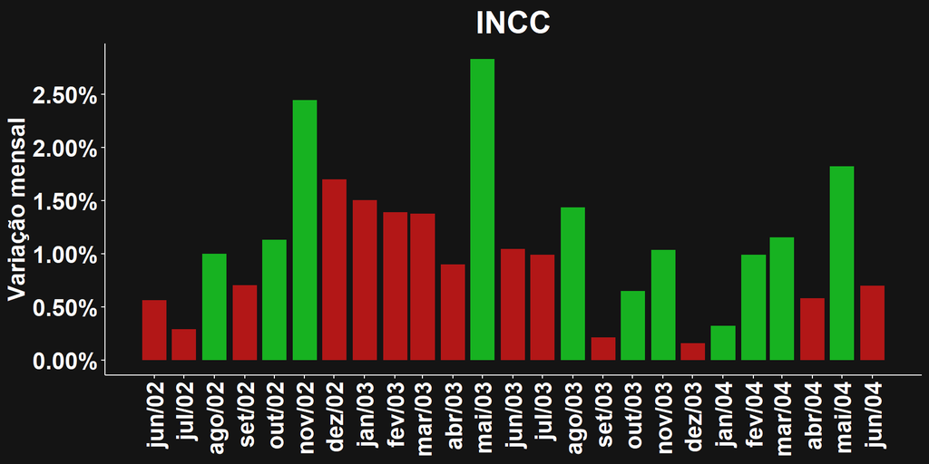

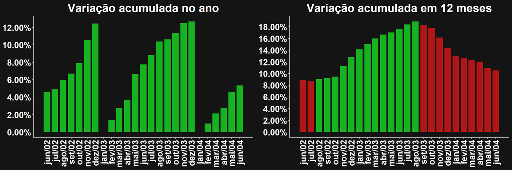

# Estatísticas

As estatísticas descritivas a seguir são feitas com base nos últimos 48 meses, e tem como objetivo possibilitar a avaliação do resultado observado em comparação aos períodos anteriores.

|  | Minimo | 1 Quartil | Mediana | Media | 3 Quartil | Maximo | Desvio Padrão |
| --- | --- | --- | --- | --- | --- | --- | --- |
| IPCA | -0.15% | 0.38% | 0.6% | 0.75% | 0.81% | 3.02% | 0.59% |
| INPC | -0.06% | 0.42% | 0.65% | 0.83% | 1.08% | 3.39% | 0.66% |
| IGP-M | -1% | 0.38% | 0.95% | 1.13% | 1.5% | 5.19% | 1.12% |
| IGP-DI | -0.7% | 0.43% | 0.85% | 1.13% | 1.6% | 5.84% | 1.14% |
| IPA | -1.68% | 0.44% | 1.09% | 1.35% | 1.93% | 7.45% | 1.6% |
| IPC | -0.16% | 0.38% | 0.65% | 0.74% | 0.86% | 3.14% | 0.61% |
| INCC | 0.16% | 0.36% | 0.65% | 0.88% | 1.14% | 2.84% | 0.64% |

Levando em consideração o desvio padrão de cada indíce, proporcionalmente os que mais se afastaram da média foram o INPC, o INCC e o IGP-M.

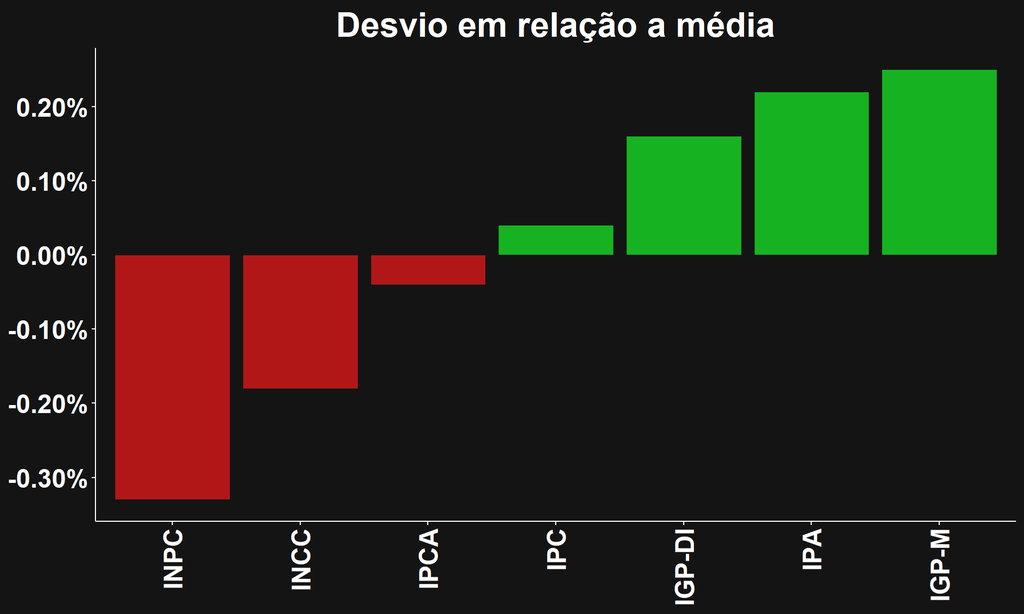

**João Victor Gomes**  
**jvg.santana@gmail.com**  
**[linkedin.com/in/jvictorgomes](https://www.linkedin.com/in/jvictorgomes/)**